# Cox Survival Analysis for HGG Samples

Run Jin

8/18/2021

## Import relevant data & select cohort of interest

```r
histology_df <- read_tsv("../data/histologies.tsv")
expression_data <- readRDS("../data/gene-expression-rsem-tpm-collapsed.rds")

cohort_df <- histology_df %>% dplyr::filter(tumor_descriptor == "Initial CNS Tumor") %>%
  dplyr::filter(experimental_strategy=="RNA-Seq") %>%
  dplyr::filter(cancer_group %in% c("High-grade glioma/astrocytoma"))

cohort_df$PFS_days <- as.numeric(cohort_df$PFS_days)
cohort_df <- cohort_df %>%
  dplyr::mutate(PFS_status = if_else(PFS_days < OS_days, 1, 0)) %>%
  dplyr::select(Kids_First_Biospecimen_ID, OS_status, OS_days, PFS_status, PFS_days, harmonized_diagnosis, CNS_region)

nrow(cohort_df)
```

```
## [1] 61
```

```r
cohort_df
```

```
## # A tibble: 61 × 7
##    Kids_First_Biospecimen_ID OS_status OS_days PFS_status PFS_days harmonized_diag…
##    <chr>                     <chr>       <dbl>      <dbl>    <dbl> <chr>
##  1 BS_052PZFMK               LIVING         NA         NA       NA High-grade glio…
##  2 BS_0C7VZC0A               LIVING       1433          0     1433 High-grade glio…
##  3 BS_0RQ4P069               DECEASED      132          1       23 High-grade glio…
##  4 BS_29X4ZX6Q               DECEASED     1139          1      985 High-grade glio…
##  5 BS_2EN3X6HB               DECEASED     1747          1     1002 High-grade glio…
##  6 BS_399RPKC9               DECEASED      389          1      216 High-grade glio…
##  7 BS_3AC3SRWH               LIVING         NA         NA       NA High-grade glio…
##  8 BS_3MS8WVNR               DECEASED      693          1      637 High-grade glio…
##  9 BS_45J79YTF               DECEASED      222          1      170 High-grade glio…
## 10 BS_4PWDGEB0               LIVING       3313          0     3313 High-grade glio…
## # … with 51 more rows, and 1 more variable: CNS_region <chr>
```

Define directory

```r
# create directory
root_dir <- rprojroot::find_root(rprojroot::has_dir(".git"))

coxph_train_results_dir <- file.path(root_dir, "molecular_target_radiation", "results", "HGG", "coxph_survival_train")

coxph_test_results_dir <- file.path(root_dir, "molecular_target_radiation", "results","HGG", "coxph_survival_test")

cox_survival_plots_dir <- file.path(root_dir, "molecular_target_radiation", "plots","HGG", "CoxPH_survival")

if (!dir.exists(coxph_train_results_dir )) {
  dir.create(coxph_train_results_dir , recursive = TRUE)
}

if (!dir.exists(coxph_test_results_dir )) {
  dir.create(coxph_test_results_dir , recursive = TRUE)
}

if (!dir.exists(cox_survival_plots_dir )) {
  dir.create(cox_survival_plots_dir , recursive = TRUE)
}
```

## Merge expression data to histology file

```r
# get biospecimen ID's for samples
cohort_bsid <- cohort_df %>% pull(Kids_First_Biospecimen_ID) %>% unique()

# subset to gene and sample of interest
expression_of_interest <- expression_data %>% dplyr::select(all_of(cohort_bsid)) %>%
  rownames_to_column("GeneSymbol") %>%
  dplyr::filter(GeneSymbol %in% c("SLC7A5", "FOLH1")) %>%
  column_to_rownames("GeneSymbol") %>%
  t() %>% as.data.frame() %>%
  rownames_to_column("Kids_First_Biospecimen_ID")

#annotate relevant clinical information to the expression data frame
combined <- expression_of_interest %>% dplyr::left_join(cohort_df)
```

## Modify histology file to mark living as 0 and deceased as 1

```r
combined_annotated <- combined %>% dplyr::filter(!is.na(OS_status)) %>%
  dplyr::mutate(os_status_level = case_when(
    OS_status == "LIVING" ~ 0,
    OS_status == "DECEASED" ~ 1
  ))

# change the columns to desired type
combined_annotated$harmonized_diagnosis <- as.factor(combined_annotated$harmonized_diagnosis)
combined_annotated$CNS_region <- as.factor(combined_annotated$CNS_region)

#the number of samples that HAVE OS_status is:
nrow(combined_annotated)
```

```
## [1] 60
```

## Build up the model for cox analysis below

```r
model_slc7a5 <- as.formula(survival::Surv(OS_days, os_status_level) ~ harmonized_diagnosis + CNS_region + SLC7A5)
model_folh1 <- as.formula(survival::Surv(OS_days, os_status_level) ~ harmonized_diagnosis + CNS_region + FOLH1)
```

## Create train test partition

```r
set.seed(236)
trainIndex <- createDataPartition(combined_annotated$OS_status, p = 0.6,
                                      list = FALSE,
                                      times = 1)
data_train <- combined_annotated[trainIndex, ]
data_test <- combined_annotated[-trainIndex, ]
```

## Run Cox Analysis on training set

First run it for SLC7A5

```r
coxph_train_slc7a5 <- survival::coxph(model_slc7a5,
                     data = data_train)
coxph_train_slc7a5_sum <- as.data.frame(summary(coxph_train_slc7a5)$coefficients, keep.rownames = T) %>%
  tibble::rownames_to_column()
coxph_train_slc7a5_sum %>% knitr::kable()
```

| rowname | coef | exp(coef) | se(coef) | z | Pr(>\|z\|) |
| --- | --- | --- | --- | --- | --- |
| harmonized_diagnosisHigh-grade glioma/astrocytoma, H3 G35-mutant | -0.9485093 | 3.873180e-01 | 1.0997603 | -0.8624692 | 0.3884294 |
| harmonized_diagnosisHigh-grade glioma/astrocytoma, H3 wildtype | 0.0402003 | 1.041019e+00 | 0.5361071 | 0.0749857 | 0.9402261 |
| harmonized_diagnosisHigh-grade glioma/astrocytoma, IDH-mutant | -1.5673797 | 2.085910e-01 | 1.3176351 | -1.1895400 | 0.2342272 |
| CNS_regionMidline | 1.8027328 | 6.066203e+00 | 0.7351930 | 2.4520540 | 0.0142043 |
| CNS_regionMixed | 0.8099520 | 2.247800e+00 | 0.7796493 | 1.0388672 | 0.2988665 |
| CNS_regionPosterior fossa | 22.2662748 | 4.678647e+09 | 7386.3221165 | 0.0030145 | 0.9975948 |
| SLC7A5 | -0.0016070 | 9.983943e-01 | 0.0133835 | -0.1200754 | 0.9044234 |

```r
coxph_train_results_os_dir <- file.path(coxph_train_results_dir, "OS")

if (!dir.exists(coxph_train_results_os_dir )) {
  dir.create(coxph_train_results_os_dir , recursive = TRUE)
}

write_tsv(coxph_train_slc7a5_sum , file.path(coxph_train_results_os_dir, "coxph_train_slc7a5_sum.tsv"))
```

Then run it for FOLH1

```r
coxph_train_folh1 <- survival::coxph(model_folh1,
                     data = data_train)
coxph_train_folh1_sum <- as.data.frame(summary(coxph_train_folh1)$coefficients, keep.rownames = T) %>%
  tibble::rownames_to_column()
coxph_train_folh1_sum %>% knitr::kable()
```

| rowname | coef | exp(coef) | se(coef) | z | Pr(>\|z\|) |
| --- | --- | --- | --- | --- | --- |
| harmonized_diagnosisHigh-grade glioma/astrocytoma, H3 G35-mutant | -1.3295804 | 2.645883e-01 | 1.1990963 | -1.1088187 | 0.2675084 |
| harmonized_diagnosisHigh-grade glioma/astrocytoma, H3 wildtype | -0.0972372 | 9.073407e-01 | 0.5492281 | -0.1770434 | 0.8594743 |
| harmonized_diagnosisHigh-grade glioma/astrocytoma, IDH-mutant | -1.2390709 | 2.896532e-01 | 1.3885858 | -0.8923257 | 0.3722184 |
| CNS_regionMidline | 1.8478597 | 6.346222e+00 | 0.7344685 | 2.5159141 | 0.0118724 |
| CNS_regionMixed | 0.6407074 | 1.897823e+00 | 0.7696709 | 0.8324434 | 0.4051587 |
| CNS_regionPosterior fossa | 22.2149580 | 4.444610e+09 | 7350.3864895 | 0.0030223 | 0.9975886 |
| FOLH1 | -0.0313695 | 9.691174e-01 | 0.0396468 | -0.7912252 | 0.4288126 |

```r
write_tsv(coxph_train_folh1_sum , file.path(coxph_train_results_os_dir,"coxph_train_folh1_sum.tsv"))
```

## Calculate risk score for training set and predict for test set

First calculate for SLC7A5

```r
train_risk_slc7a5 <- predict(coxph_train_slc7a5, type = "risk")
med_risk_slc7a5 <- median(train_risk_slc7a5)
med_risk_slc7a5
```

```
## [1] 1.048011
```

```r
test_risk_slc7a5 <- predict(coxph_train_slc7a5, newdata = data_test, type = "risk") %>%
  as.data.frame() %>% cbind(data_test) %>%
  dplyr::rename("RiskScore" = ".") %>%
  dplyr::mutate(RiskGroup = case_when(
    RiskScore > med_risk_slc7a5 ~ "High",
    RiskScore <= med_risk_slc7a5 ~ "Low"
  ))

test_risk_slc7a5$RiskGroup <- as.factor(test_risk_slc7a5$RiskGroup)
```

Then calculate for FOLH1

```r
train_risk_folh1 <- predict(coxph_train_folh1, type = "risk")
med_risk_folh1 <- median(train_risk_folh1)
med_risk_folh1
```

```
## [1] 1.034971
```

```r
test_risk_folh1 <- predict(coxph_train_folh1, newdata = data_test, type = "risk") %>%
  as.data.frame() %>% cbind(data_test) %>%
  dplyr::rename("RiskScore" = ".") %>%
  dplyr::mutate(RiskGroup = case_when(
    RiskScore > med_risk_folh1 ~ "High",
    RiskScore <= med_risk_folh1 ~ "Low"
  ))

test_risk_folh1$RiskGroup <- as.factor(test_risk_folh1$RiskGroup)
```

## Now run Cox analyses per gene for RiskScore and RiskGroup

First calculate per risk group for SLC7A5

```r
coxph_riskgroup_slc7a5 <- survival::coxph(formula = Surv(OS_days, os_status_level) ~  RiskGroup,
                     data = test_risk_slc7a5)
coxph_riskgroup_slc7a5_sum <- as.data.frame(summary(coxph_riskgroup_slc7a5)$coefficients) %>%
  rownames_to_column()
coxph_riskgroup_slc7a5_sum %>% knitr::kable()
```

| rowname | coef | exp(coef) | se(coef) | z | Pr(>\|z\|) |
| --- | --- | --- | --- | --- | --- |
| RiskGroupLow | -1.047654 | 0.3507595 | 0.5661005 | -1.850651 | 0.0642198 |

Calculate per risk score for SLC7A5

```r
coxph_riskscore_slc7a5 <- survival::coxph(formula = Surv(OS_days, os_status_level) ~  RiskScore,
                     data = test_risk_slc7a5)
coxph_riskscore_slc7a5_sum <- as.data.frame(summary(coxph_riskscore_slc7a5)$coefficients) %>%
  rownames_to_column()
coxph_riskscore_slc7a5_sum %>% knitr::kable()
```

| rowname | coef | exp(coef) | se(coef) | z | Pr(>\|z\|) |
| --- | --- | --- | --- | --- | --- |
| RiskScore | 0 | 1 | 0 | 1.518013 | 0.129011 |

Saving results for SLC7A5 results:

```r
coxph_test_results_os_dir <- file.path(coxph_test_results_dir, "OS")

if (!dir.exists(coxph_test_results_os_dir )) {
  dir.create(coxph_test_results_os_dir , recursive = TRUE)
}

write_tsv(coxph_riskgroup_slc7a5_sum, file.path(coxph_test_results_os_dir, "coxph_test_riskgroup_slc7a5_sum.tsv"))
write_tsv(coxph_riskscore_slc7a5_sum, file.path(coxph_test_results_os_dir, "coxph_test_riskscore_slc7a5_sum.tsv"))
```

Then calculate per risk group for FOLH1

```r
coxph_riskgroup_folh1 <- survival::coxph(formula = Surv(OS_days, os_status_level) ~  RiskGroup,
                     data = test_risk_folh1)
coxph_riskgroup_folh1_sum <- as.data.frame(summary(coxph_riskgroup_folh1)$coefficients) %>%
  rownames_to_column()
coxph_riskgroup_folh1_sum %>% knitr::kable()
```

| rowname | coef | exp(coef) | se(coef) | z | Pr(>\|z\|) |
| --- | --- | --- | --- | --- | --- |
| RiskGroupLow | -0.286567 | 0.7508368 | 0.5292292 | -0.5414799 | 0.5881768 |

Calculate per risk score for FOLH1

```r
coxph_riskscore_folh1 <- survival::coxph(formula = Surv(OS_days, os_status_level) ~  RiskScore,
                     data = test_risk_folh1)
coxph_riskscore_folh1_sum <- as.data.frame(summary(coxph_riskscore_folh1)$coefficients) %>%
  rownames_to_column()
coxph_riskscore_folh1_sum %>% knitr::kable()
```

| rowname | coef | exp(coef) | se(coef) | z | Pr(>\|z\|) |
| --- | --- | --- | --- | --- | --- |
| RiskScore | 0 | 1 | 0 | 1.480782 | 0.1386648 |

Saving results for FOLH1 results:

```r
write_tsv(coxph_riskgroup_folh1_sum, file.path(coxph_test_results_os_dir, "coxph_test_riskgroup_folh1_sum.tsv"))
write_tsv(coxph_riskscore_folh1_sum, file.path(coxph_test_results_os_dir, "coxph_test_riskscore_folh1_sum.tsv"))
```

## Finally plot the survival for each gene per risk group

First generate plot for SLC7A5

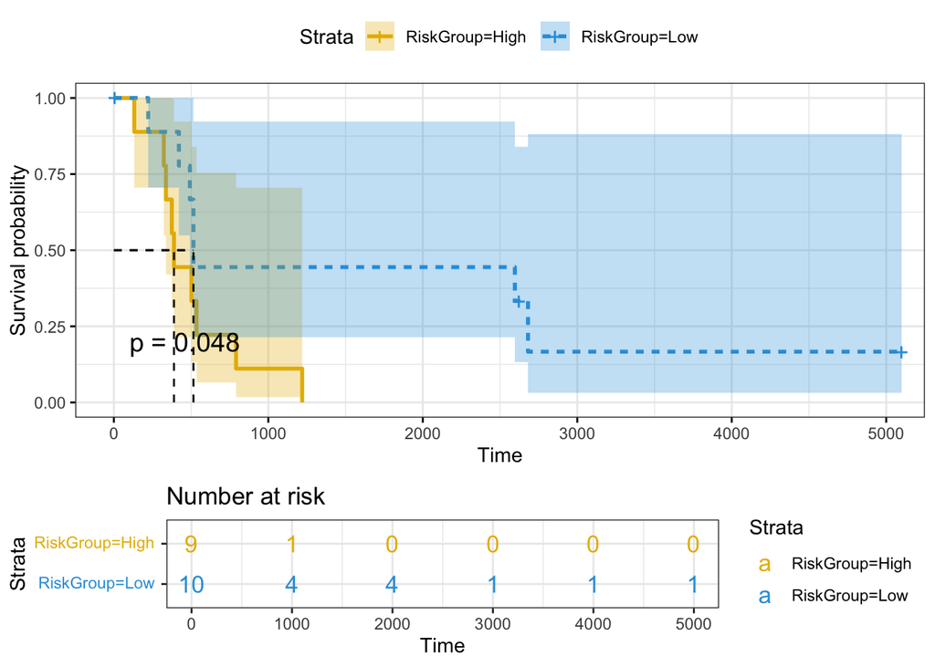

```r
fit_slc7c5 <- survfit(Surv(OS_days, os_status_level) ~ RiskGroup, data = test_risk_slc7a5)
plot_coxph_riskgroup_slc7a5 <- survminer::ggsurvplot(fit_slc7c5,
           data=test_risk_slc7a5,
           pval = TRUE,
           conf.int = TRUE,
           risk.table = TRUE, # Add risk table
           risk.table.col = "strata", # Change risk table color by groups
           linetype = "strata", # Change line type by groups
           surv.median.line = "hv", # Specify median survival
           ggtheme = theme_bw(), # Change ggplot2 theme
           palette = c("#E7B800", "#2E9FDF"))

# Make this plot a combined plot
surv_plot_slc7a5 <- cowplot::plot_grid(plot_coxph_riskgroup_slc7a5[[1]],
                                       plot_coxph_riskgroup_slc7a5[[2]],
                                       nrow = 2,
                                       rel_heights = c(2.5, 1))
# Print it out here
surv_plot_slc7a5
```

```r
cox_survival_plots_os_dir <- file.path(cox_survival_plots_dir, "OS")
if (!dir.exists(cox_survival_plots_os_dir )) {
  dir.create(cox_survival_plots_os_dir , recursive = TRUE)
}

# Save the plot
cowplot::save_plot(filename = file.path(cox_survival_plots_os_dir, "coxph_riskgroup_slc7a5_survival.png"), plot = surv_plot_slc7a5)
```

Second generate plot for FOLH1

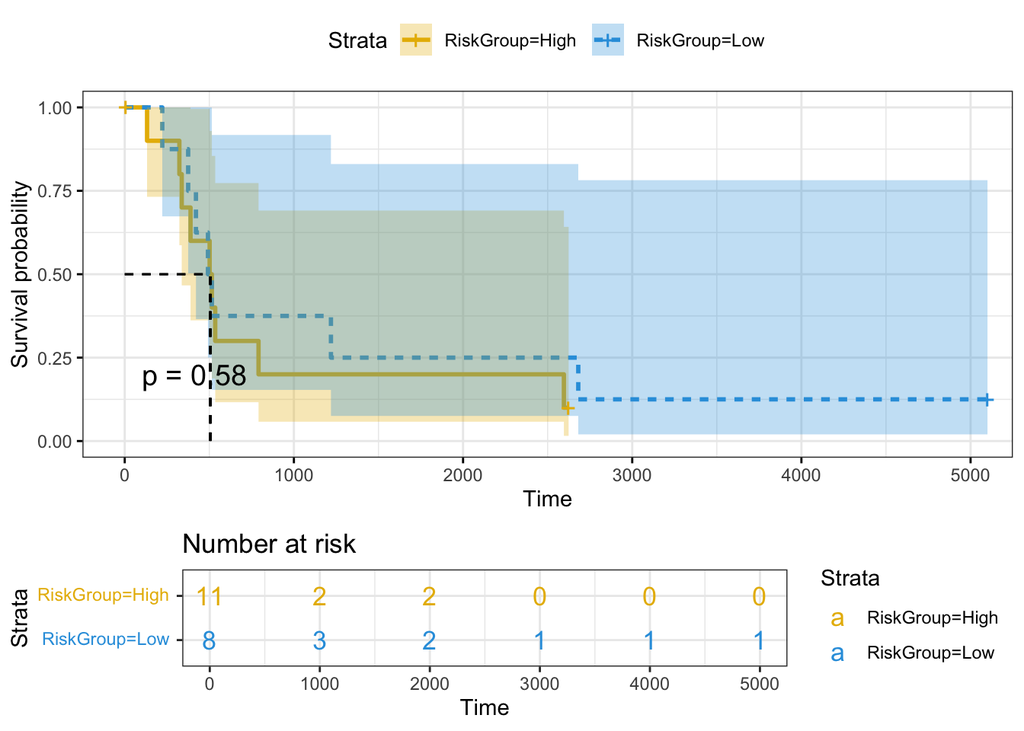

```r
fit_folh1 <- survfit(Surv(OS_days, os_status_level) ~ RiskGroup, data = test_risk_folh1)
plot_coxph_riskgroup_folh1 <- survminer::ggsurvplot(fit_folh1,
           data=test_risk_folh1,
           pval = TRUE,
           conf.int = TRUE,
           risk.table = TRUE, # Add risk table
           risk.table.col = "strata", # Change risk table color by groups
           linetype = "strata", # Change line type by groups
           surv.median.line = "hv", # Specify median survival
           ggtheme = theme_bw(), # Change ggplot2 theme
           palette = c("#E7B800", "#2E9FDF"))

# Make this plot a combined plot
surv_plot_folh1 <- cowplot::plot_grid(plot_coxph_riskgroup_folh1[[1]],
                                      plot_coxph_riskgroup_folh1[[2]],
                                      nrow = 2,
                                      rel_heights = c(2.5, 1))
# Print it out here
surv_plot_folh1
```

```r
# Save the plot
cowplot::save_plot(filename = file.path(cox_survival_plots_os_dir, "coxph_riskgroup_folh1_survival.png"), plot = surv_plot_folh1)
```